# Xcertainty

KC Bierlich & Josh Hewitt, CODEX

2024-10-25

## Introduction

All morphological measurements derived using drone-based photogrammetry are susceptible to uncertainty. This uncertainty often varies by the drone system used. Thus, it is critical to incorporate photogrammetric uncertainty associated with measurements collected using different drones so that results are robust and comparable across studies and over long-term datasets.

The `Xcertainty` package makes this simple and easy by producing a predictive posterior distribution for each measurement. This posterior distribution can be summarized to describe the measurement (i.e., mean, median) and its associated uncertainty (i.e., standard deviation, credible intervals). The posterior distributions are also useful for making probabilistic statements, such as classifying maturity or diagnosing pregnancy if a proportion of the posterior distribution for a given measurement is greater than a specified threshold (e.g., if greater than 50% of posterior distribution for total body length is > 10 m, the individual is classified as mature).

`Xcertainty` is based off the Bayesian statistical model described in [Bierlich et al., 2021a](https://doi.org/10.3354/meps13814) where measurements of known-sized objects (‘calibration objects’) collected at various altitudes are used as training data to predict morphological measurements (e.g., body length) and associated uncertainty of unknown-sized objects (e.g., whales). This modeling approach was later adapted to incorporate multiple measurements (body length and width) to estimate body condition with associated uncertainty [Bierlich et al. (2021b)](https://doi.org/10.3389/fmars.2021.749943), as well as combine body length with age information to construct growth curves [Bierlich et al., 2023](https://doi.org/10.1098/rsbl.2023.0043) and [Pirotta and Bierlich et al., 2024](https://doi.org/10.1111/gcb.17366).

In this vignette, we’ll cover how to setup your data, run `Xcertainty`, calculate body condition metrics, and interpret results.

## Main inputs

`Xcertainty` follows these main steps.

1. Prepare calibration and observation data:
   - `parse_observations()`: parses wide-format data into a normalized list of dataframe objects.
2. Build sampler:
   - 2a. Calibration Objects
     - `calibration_sampler()`: estimate measurement error parameters for calibration/training data.
   - 2b. Observation Data
     - `independent_length_sampler()`: this model assumes all Subject/Measurement/Timepoint combinations are independent. So this is well suited for data that contains individuals that either have no replicate samples or have replicate samples that are independent over time, such as body condition which can increase or decrease, as opposed to length which should be stable or increase over time.
     - `nondecreasing_length_sampler()`: data contains individuals with replicate samples for length over time but no age information. This sampler sets a rule so that length measurements of an individual cannot shrink over time (from year to year), i.e., an individual should not (in most cases!) be getting shorter over time.
     - `growth_curve_sampler()`: data contains individuals with replicate samples and age information. This model fits a Von Bertalanffy-Putter growth curve to observations following [Pirotta and Bierlich et al., 2024](https://doi.org/10.1111/gcb.17366).
3. Run!
   - `sampler()`: this function runs the sampler that you built. You can set the number of iterations using ‘niter’.

## Example: Gray whale body length and body condition

We will use a small example dataset consisting of body length and body width measurements of Pacific Coast Feeding Group (PCFG) gray whales imaged along the coast of Newport, Oregon, USA using two different drones, a DJI Inspire 2 (I2, n = 5 individuals) and a DJI Phantom 4 Pro (P4P, n = 5 individuals). The P4P contains only a barometer for estimating altitude, while the I2 contains both a barometer and a LiDAR (or laser) altimeter (LidarBoX, [Bierlich et al., 2024](https://doi.org/10.1139/dsa-2023-0051)). In this example, we will use data from the I2 (see Xcertianty_informative_priors for an example using P4P data).

We will use the length and width measurements to calculate several body condition metrics (body area index, body volume, surface area, and standardized widths). We used open-source software [MorphoMetriX v2](https://github.com/MMI-CODEX/MorphoMetriX-V2) and [CollatriX](https://github.com/cbirdferrer/collatrix) to measure the whales and process the measurements, respectively.

Steps:  
1. Prepare calibration data and observation (whale) data.  
2. Build sampler.  
3. Run the sampler.  
4. Calculate body condition metrics.  
5. View outputs.

We’ll first load the Xcertainty package, as well as other packages we will use throughout this example.

```r
library(Xcertainty)

library(tidyverse)
library(ggdist)
```

### Calibration Objects

First we’ll load and prepare the calibration data, which is from [Bierlich et al., 2024](https://doi.org/10.1139/dsa-2023-0051). Note that “CO” here stands for “Calibration Object” used for training data, and “CO.L” is the true length of the CO (1 m) and “Lpix” is the photogrammetric measurement of the CO in pixels. Each UAS has a unique CO.ID so that the training data and observation (whale) data can be linked. We will filter to use CO data from the I2 drone.

```r
# load calibration measurement data
data("co_data")

# sample size for both drones
table(co_data$uas)
```

```
##
##  I2 P4P
##  49  69
```

```r
# filter for I2 drone
co_data_I2 <- co_data %>% filter(uas == "I2")
```

Next, well format the data using `parse_observations()`.

```r
calibration_data = parse_observations(
  x = co_data_I2,
  subject_col = 'CO.ID',
  meas_col = 'Lpix',
  tlen_col = 'CO.L',
  image_col = 'image',
  barometer_col = 'Baro_Alt',
  laser_col = 'Laser_Alt',
  flen_col = 'Focal_Length',
  iwidth_col = 'Iw',
  swidth_col = 'Sw',
  uas_col = 'uas'
)
```

This creates a list of four elements:  
* `calibration_data$pixel_counts`.  
* `calibration_data$training_objects`.  
* `calibration_data$image_info`. * `calibration_data$prediction_objects`

### Gray whale measurements

Now we’ll load and prepare the gray whale measurement data. The column ‘whale_ID’ denotes the unique individual. Note, some individuals have multiple images – Xcertainty incorporates measurements across images for an individual to produce a single posterior distribution for the measurement of that individual. For example, multiple body length measurements from different images of an individual will produce a single posterior distribution of body length for that individual.

To estimate body condition for these gray whales, we will use body widths between 20-70% of the body length. We’ll save the column names of these widths as their own object.

For this example, we will only use whale measurements collected using the I2 drone. See the vignette titled “Xcertainty_informative_prios” for an example using P4P data. Note, that Xcertainty can also incorporate measurements with missing LiDAR data (NAs).

```r
# load gray whale measurement data
data("gw_data")

# quick look at the data
head(gw_data)
```

```
## # A tibble: 6 × 34
##   whale_ID image   year   DOY uas   Focal…¹ Focal…²    Sw    Iw Baro_…³ Launc…⁴ Baro_…⁵ Laser…⁶ CO.ID TL_px TL_w0…⁷ TL_w1…⁸ TL_w1…⁹
##   <chr>    <chr>  <int> <int> <chr>   <dbl>   <dbl> <dbl> <int>   <dbl>   <dbl>   <dbl>   <dbl> <chr> <dbl>   <dbl>   <dbl>   <dbl>
## 1 GW_01    image…  2022   233 I2       25      NA    17.3  3840    41.8    1.72    43.5    44.3 CO_I… 1536.    83.5   117.     154.
## 2 GW_02    image…  2019   249 P4P       8.8     9.2  13.2  3840    25.6    1.72    27.3    NA   CO_P… 1185.    68.9    97.0    107.
## 3 GW_02    image…  2019   249 P4P       8.8     9.2  13.2  3840    25.6    1.72    27.3    NA   CO_P… 1203.    68.9    91.9    107.
## 4 GW_03    image…  2022   191 I2       25      NA    17.3  3840    46.7    1.72    48.4    47.5 CO_I…  951.    57.4    87.5    107.
## 5 GW_03    image…  2022   191 I2       25      NA    17.3  3840    47      1.72    48.7    46.5 CO_I…  959.    59.8    86.9    109.
## 6 GW_04    image…  2022   209 I2       25      NA    17.3  3840    29.5    2.18    31.7    29.0 CO_I… 1925.   102.    138.     181.
## # … with 16 more variables: TL_w20.00_px <dbl>, TL_w25.00_px <dbl>, TL_w30.00_px <dbl>, TL_w35.00_px <dbl>, TL_w40.00_px <dbl>,
## #   TL_w45.00_px <dbl>, TL_w50.00_px <dbl>, TL_w55.00_px <dbl>, TL_w60.00_px <dbl>, TL_w65.00_px <dbl>, TL_w70.00_px <dbl>,
## #   TL_w75.00_px <dbl>, TL_w80.00_px <dbl>, TL_w85.00_px <dbl>, TL_w90.00_px <dbl>, TL_w95.00_px <dbl>, and abbreviated variable
## #   names ¹Focal_Length, ²Focal_Length_adj, ³Baro_raw, ⁴Launch_Ht, ⁵Baro_Alt, ⁶Laser_Alt, ⁷TL_w05.00_px, ⁸TL_w10.00_px,
## #   ⁹TL_w15.00_px
```

```r
# number of images per whale ID
table(gw_data$whale_ID)
```

```
##
## GW_01 GW_02 GW_03 GW_04 GW_05 GW_06 GW_07 GW_08 GW_09 GW_10
##     1     2     2     1     2     1     1     1     1     3
```

```r
# filter for I2 drone and select specific widths to include for estimating body condition (20-70%)
gw_measurements <- gw_data %>% filter(uas == "I2") %>%
  select(!c("TL_w05.00_px", "TL_w10.00_px", "TL_w15.00_px",
            "TL_w75.00_px", "TL_w80.00_px", "TL_w85.00_px", "TL_w90.00_px", "TL_w95.00_px"))

# identify the width columns in the dataset
width_names = grep(
  pattern = 'TL_w\\_*',
  x = colnames(gw_measurements),
  value = TRUE
)
```

Next, we’ll use `parse_observations()` to prepare the whale data. Since `Xcertainty` incorporates errors associated with both a LiDAR altimeter and a barometer into the output measurement, the input measurements must be in pixels. In our example dataset of gray whales, measurements are already in pixels. If measurements in a dataframe are in meters, they can easily be converted into pixels using `alt_conversion_col` to assign which altitude column should be used to “back calculate” measurements in meters into pixels. For example, use `alt_conversion_col = 'Baro_Alt` if the measurements used the barometer to convert measurements into meters.

Note that you can also set the specific timepoint to link measurements of individuals using `timepoint_col`. For example, if you wanted all the total body length measurements of an individual included to produce a single length measurement over the course of the season, you may choose `timepoint_col = 'year'`, or you may want body condition at the daily level, so you could enter `timepoint_col = 'date'`. In our example, measurements are already synced at the daily level, so we will keep default as is.

Also, note that we assign the measurement column (`meas_col`) for TL and the widths between 20-70% that we saved as “width_names”.

```r
# parse field study
whale_data = parse_observations(
  x = gw_measurements,
  subject_col = 'whale_ID',
  meas_col = c('TL_px', width_names),
  image_col = 'image',
  barometer_col = 'Baro_Alt',
  laser_col = 'Laser_Alt',
  flen_col = 'Focal_Length',
  iwidth_col = 'Iw',
  swidth_col = 'Sw',
  uas_col = 'uas'
  #alt_conversion_col = 'altitude'
)
```

This creates a list of four elements:  
* `calibration_data$pixel_counts`.  
* `calibration_data$training_objects`.  
* `calibration_data$image_info`. * `calibration_data$prediction_objects`

## Build sampler

Now we will build a sampler. Always start with using non-informative priors, which should be appropriate for most datasets. In some cases, using informative priors may be more appropriate, especially for datasets that have high errors and when the model is overparameterized – see the vignette “Xcertianty_informative_priors” for an example. We’ll set the altitudes (`image_altitude`) and object length measurements (`object_lengths`) to cover an overly wide range for our target species.

```r
sampler = independent_length_sampler(
  data = combine_observations(calibration_data, whale_data),
  priors = list(
    image_altitude = c(min = 0.1, max = 130),
    altimeter_bias = rbind(
      data.frame(altimeter = 'Barometer', mean = 0, sd = 1e2),
      data.frame(altimeter = 'Laser', mean = 0, sd = 1e2)
    ),
    altimeter_variance = rbind(
      data.frame(altimeter = 'Barometer', shape = .01, rate = .01),
      data.frame(altimeter = 'Laser', shape = .01, rate = .01)
    ),
    altimeter_scaling = rbind(
      data.frame(altimeter = 'Barometer', mean = 1, sd = 1e1),
      data.frame(altimeter = 'Laser', mean = 1, sd = 1e1)
    ),
    pixel_variance = c(shape = .01, rate = .01),
    object_lengths = c(min = .01, max = 20)
  )
)
```

```
## Defining model
## Building model
## Setting data and initial values
## Running calculate on model [Note] Any error reports that follow may simply reflect missing values in model variables.
## Checking model sizes and dimensions
## Compiling [Note] This may take a minute. [Note] Use 'showCompilerOutput = TRUE' to see C++ compilation details.
```

```
## ===== Monitors =====
## thin = 1: altimeter_bias, altimeter_scaling, altimeter_variance, image_altitude, object_length, pixel_variance
## ===== Samplers =====
## RW sampler (117)
##   - image_altitude[]  (57 elements)
##   - object_length[]  (60 elements)
## conjugate sampler (7)
##   - altimeter_bias[]  (2 elements)
##   - altimeter_scaling[]  (2 elements)
##   - altimeter_variance[]  (2 elements)
##   - pixel_variance
```

```
## Compiling
##   [Note] This may take a minute.
##   [Note] Use 'showCompilerOutput = TRUE' to see C++ compilation details.
```

## Run Sampler

Now we can run the sampler. Note, that “niter” refers to the number of iterations. When exploring data outputs, 1e4 or 1e5 can be good place for exploration, as this won’t take too much time to run. We recommend using 1e6 for the final analysis since 1e6 MCMC samples is often enough to get a reasonable posterior effective sample size.

```r
# run sampler
output = sampler(niter = 1e6, thin = 10)
```

```
## Sampling
```

```
## |-------------|-------------|-------------|-------------|
## |-------------------------------------------------------|
```

```
## Extracting altimeter output
```

```
## Extracting image output
```

```
## Extracting pixel error output
```

```
## Extracting object output
```

```
## Extracting summaries
```

## View Sampler Outputs (TL and widths)

Our saved `output` contains all the posterior samples and summaries of all training data and length and width measurements from the sampler. **Note**, that there are many objects stored in `output`, so it is best to view specific selections rather than viewing all of the objects stored in `output` at once, as this can take a very long time to load and cause R to freeze.

We can view the posterior summaries (mean, sd, etc.) for each altimeter. Note that the `lower` and `upper` represent the 95% highest posterior density intervals (HPDI) of the posterior distribution.

```r
output$summaries$altimeters
```

```
##   UAS altimeter parameter       mean         sd      lower    upper       ESS   PSS
## 1  I2 Barometer      bias -0.7203422 1.57906441 -3.7660942 2.423896  1906.974 50001
## 2  I2 Barometer  variance  5.4004467 1.13193409  3.3639491 7.613621 12398.181 50001
## 3  I2 Barometer   scaling  1.0032498 0.04093036  0.9236957 1.083940  1463.894 50001
## 4  I2     Laser      bias -0.5243021 1.62965603 -3.5940199 2.778073  2475.701 50001
## 5  I2     Laser  variance  6.0155576 1.30824124  3.7594362 8.681424  3291.101 50001
## 6  I2     Laser   scaling  0.9983718 0.04207249  0.9144538 1.078665  1788.535 50001
```

And we can view and compare the posterior outputs for each image’s altitude compared to the observed altitude from the barometer (blue) and LiDAR (orange) in the training dataset.

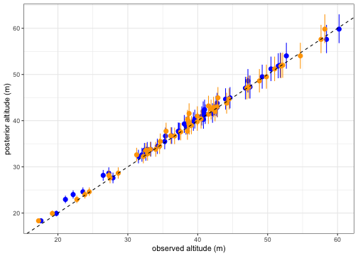

```r
output$summaries$images %>% left_join(co_data %>% rename(Image = image), by = "Image") %>%
  ggplot() + theme_bw() +
  geom_pointrange(aes(x = Baro_Alt, y = mean, ymin = lower, ymax = upper), color = "blue") +
  geom_pointrange(aes(x = Laser_Alt, y = mean, ymin = lower, ymax = upper), color = "orange") +
  geom_abline(slope = 1, intercept = 0, lty = 2) +
  ylab("posterior altitude (m)") + xlab("observed altitude (m)")
```

We can also view the pixel variance from the training data

```r
output$pixel_error$summary
```

```
##   error parameter     mean      sd    lower    upper      ESS   PSS
## 1 pixel  variance 18.74745 3.68237 12.24157 26.13657 19027.86 50001
```

We can view the posterior summaries (mean, sd, etc.) for all measurements of each individual whale. As above, the `lower` and `upper` represent the 95% HPDI of the posterior distribution for that specific measurement.

```r
head(output$summaries$objects)
```

```
##   Subject  Measurement Timepoint parameter      mean         sd     lower     upper      ESS   PSS
## 1   GW_01        TL_px         1    length 12.524335 0.48432091 11.605177 13.486068 247.0445 50001
## 2   GW_01 TL_w20.00_px         1    length  1.557421 0.06986998  1.421111  1.693672 354.2822 50001
## 3   GW_01 TL_w25.00_px         1    length  1.915799 0.08184221  1.755663  2.074863 312.8519 50001
## 4   GW_01 TL_w30.00_px         1    length  2.059340 0.08710605  1.889557  2.229407 300.9867 50001
## 5   GW_01 TL_w35.00_px         1    length  2.124176 0.08910634  1.953447  2.298639 306.4567 50001
## 6   GW_01 TL_w40.00_px         1    length  2.123675 0.08898825  1.950219  2.296821 302.6361 50001
```

You can filter to view a specific measurement across all individuals, such as total body length (TL).

```r
output$summaries$objects %>% filter(Measurement == "TL_px")
```

```
##   Subject Measurement Timepoint parameter      mean        sd     lower     upper       ESS   PSS
## 1   GW_01       TL_px         1    length 12.524335 0.4843209 11.605177 13.486068 247.04452 50001
## 2   GW_03       TL_px         1    length  8.388758 0.2217488  7.951812  8.820734 661.61972 50001
## 3   GW_04       TL_px         1    length 11.076464 0.5931233  9.846138 12.232099  90.86436 50001
## 4   GW_06       TL_px         1    length 10.083364 0.5566169  8.972447 11.189054  79.22054 50001
## 5   GW_10       TL_px         1    length  9.642295 0.2222675  9.224671 10.086814 580.03644 50001
```

Or filter directly for all measurements from a specific individual

```r
output$summaries$objects %>% filter(Subject == "GW_01")
```

```
##    Subject  Measurement Timepoint parameter       mean         sd      lower      upper      ESS   PSS
## 1    GW_01        TL_px         1    length 12.5243348 0.48432091 11.6051773 13.4860681 247.0445 50001
## 2    GW_01 TL_w20.00_px         1    length  1.5574212 0.06986998  1.4211114  1.6936719 354.2822 50001
## 3    GW_01 TL_w25.00_px         1    length  1.9157989 0.08184221  1.7556626  2.0748630 312.8519 50001
## 4    GW_01 TL_w30.00_px         1    length  2.0593397 0.08710605  1.8895567  2.2294066 300.9867 50001
## 5    GW_01 TL_w35.00_px         1    length  2.1241764 0.08910634  1.9534471  2.2986388 306.4567 50001
## 6    GW_01 TL_w40.00_px         1    length  2.1236754 0.08898825  1.9502195  2.2968207 302.6361 50001
## 7    GW_01 TL_w45.00_px         1    length  2.0252817 0.08576307  1.8535119  2.1883678 324.2996 50001
## 8    GW_01 TL_w50.00_px         1    length  1.8840753 0.08067743  1.7292383  2.0439870 316.5492 50001
## 9    GW_01 TL_w55.00_px         1    length  1.6956336 0.07438487  1.5523218  1.8433656 338.3559 50001
## 10   GW_01 TL_w60.00_px         1    length  1.3357929 0.06237047  1.2158972  1.4593491 393.8830 50001
## 11   GW_01 TL_w65.00_px         1    length  1.1042666 0.05542504  0.9977178  1.2149580 456.8998 50001
## 12   GW_01 TL_w70.00_px         1    length  0.9011541 0.04933852  0.8044088  0.9975533 596.1318 50001
```

Plot total body length with associated uncertainty for each individual. Here the black dots represent the mean of the posterior distribution for total body length and the black bars around each dot represents the uncertainty, as 95% HPDI.

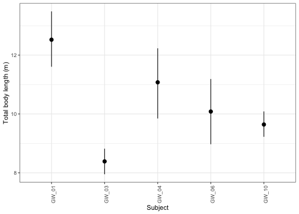

```r
output$summaries$objects %>% filter(Measurement == "TL_px") %>%
  ggplot() + theme_bw() +
  geom_pointrange(aes(x = Subject, y = mean, ymin =lower, ymax = upper)) +
  theme(axis.text.x = element_text(angle = 90, vjust = 1, hjust=1)) +
  ylab("Total body length (m)")
```

You can also view and plot the posterior samples for an individual’s measurement. Note, be sure to exclude the first half of the posterior samples, i.e., if 10000 samples, exclude the first 5000. To demonstrate this below, we’ll first save the samples for an individual as an object, then plot the distribution with the first half of the samples excluded.

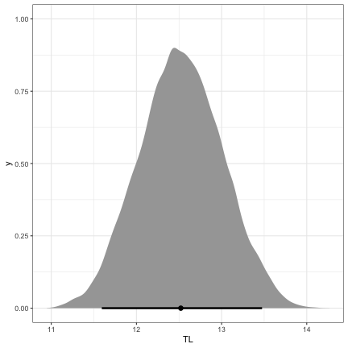

```r
ID_samples <- output$objects$`GW_01 TL_px 1`$samples

data.frame(TL = ID_samples[(length(ID_samples)/2):length((ID_samples))]) %>%
  ggplot() + stat_halfeye(aes(TL), .width = 0.95) + theme_bw()
```

### Body Condition

We’ll also calculate body condition from the posterior samples using `body_condition()`, which calculates several body condition metrics using the posterior distributions of the body widths:

- body area index (BAI) [Burnett et al., 2018](https://doi.org/10.1111/mms.12527); [Bierlich et al. (2021b)](https://doi.org/10.3389/fmars.2021.749943)
- body volume [Christiansen et al. 2021](https://doi.org/10.3354/meps13585)
- surface area [Christiansen et al., 2016](https://doi.org/10.1002/ecs2.1468)
- standardized body widths (standardized by TL).

Note, for calculating body volume, the default for `height_ratios` is 1, implying that the vertical cross section of the animal is circular rather than elliptical. To calculate body volume using an elliptical model [i.e., Christiansen et al., 2019](https://doi.org/10.1111/2041-210X.13298), enter the the height-width ratio for each width using `height_ratios`.

```r
# First, enumerate the width locations along the animal's length
width_increments = as.numeric(
  str_extract(
    string = width_names,
    pattern = '[0-9]+'
  )
)

# Compute body condition
body_condition_output = body_condition(
  data = whale_data,
  output = output,
  length_name = 'TL_px',
  width_names = width_names,
  width_increments = width_increments,
  summary.burn = .5,
  height_ratios = rep(1, length(width_names)) # assumes circular cross section
)
```

Note, there are a lot of objects stored in the `body_condition_output`, so it’s best to view selected outputs rather than all objects at once, as it may take a long time to load and can freeze R.

You can view the body condition summaries (`surface_area`, `body_area_index`, `body_volume`, and `standardized_widths`) across individuals using `body_condition_output$summaries`. Summaries include mean, standard deviation (sd) and the lower and upper 95% HPDI.

View summary of BAI

```r
head(body_condition_output$summaries$body_area_index)
```

```
##   Subject Timepoint          metric     mean        sd    lower    upper
## 1   GW_01         1 body_area_index 27.94158 0.1899036 27.56974 28.31794
## 2   GW_03         1 body_area_index 29.64340 0.2194318 29.20917 30.06942
## 3   GW_04         1 body_area_index 25.38457 0.1493190 25.08816 25.67488
## 4   GW_06         1 body_area_index 29.02524 0.1561085 28.71666 29.33080
## 5   GW_10         1 body_area_index 25.69888 0.1715854 25.36228 26.03709
```

Plot BAI results

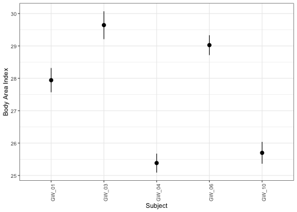

```r
body_condition_output$summaries$body_area_index %>%
  ggplot() + theme_bw() +
  geom_pointrange(aes(x = Subject, y = mean, ymin =lower, ymax = upper)) +
  theme(axis.text.x = element_text(angle = 90, vjust = 1, hjust=1)) +
  ylab("Body Area Index")
```

View summary of Body Volume

```r
head(body_condition_output$summaries$body_volume)
```

```
##   Subject Timepoint      metric     mean        sd     lower    upper
## 1   GW_01         1 body_volume 7.198659 1.1720632 5.0196814 9.562925
## 2   GW_03         1 body_volume 1.133694 0.2024182 0.7568319 1.541614
## 3   GW_04         1 body_volume 2.977343 0.8003176 1.3535517 4.498887
## 4   GW_06         1 body_volume 2.991911 0.8302595 1.4202708 4.590484
## 5   GW_10         1 body_volume 1.389413 0.2091401 0.9990588 1.804546
```

Plot Body Volume results

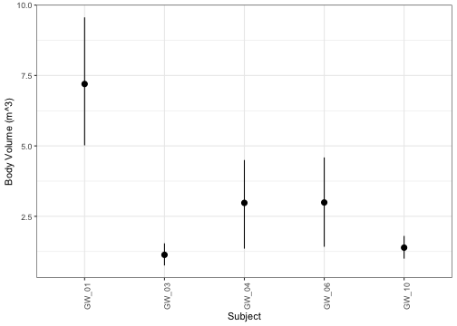

```r
body_condition_output$summaries$body_volume %>%
  ggplot() + theme_bw() +
  geom_pointrange(aes(x = Subject, y = mean, ymin =lower, ymax = upper)) +
  theme(axis.text.x = element_text(angle = 90, vjust = 1, hjust=1)) +
  ylab("Body Volume (m^3)")
```

View the standardized widths of an individual

```r
body_condition_output$summaries$standardized_widths %>% filter(Subject == "GW_01")
```

```
##    Subject Timepoint                           metric       mean          sd      lower      upper
## 1    GW_01         1 standardized_widths TL_w20.00_px 0.12435204 0.002844696 0.11869407 0.12988727
## 2    GW_01         1 standardized_widths TL_w25.00_px 0.15296737 0.002843284 0.14751147 0.15869552
## 3    GW_01         1 standardized_widths TL_w30.00_px 0.16442783 0.002858026 0.15871670 0.16996211
## 4    GW_01         1 standardized_widths TL_w35.00_px 0.16960595 0.002875781 0.16397768 0.17528082
## 5    GW_01         1 standardized_widths TL_w40.00_px 0.16956575 0.002845112 0.16389580 0.17501113
## 6    GW_01         1 standardized_widths TL_w45.00_px 0.16170918 0.002870934 0.15611762 0.16742107
## 7    GW_01         1 standardized_widths TL_w50.00_px 0.15043494 0.002861558 0.14486040 0.15607492
## 8    GW_01         1 standardized_widths TL_w55.00_px 0.13538822 0.002852321 0.12975228 0.14090144
## 9    GW_01         1 standardized_widths TL_w60.00_px 0.10665678 0.002825367 0.10123983 0.11232551
## 10   GW_01         1 standardized_widths TL_w65.00_px 0.08816989 0.002824945 0.08265540 0.09373741
## 11   GW_01         1 standardized_widths TL_w70.00_px 0.07195395 0.002827889 0.06639327 0.07756519
```

Plot standardized widths of an individual

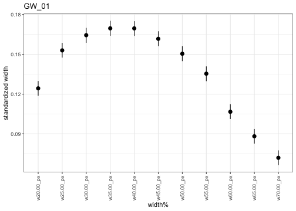

```r
body_condition_output$summaries$standardized_widths$metric <- gsub("standardized_widths TL_", "", body_condition_output$summaries$standardized_widths$metric)

body_condition_output$summaries$standardized_widths %>% filter(Subject == "GW_01") %>%
  ggplot() + theme_bw() +
  geom_pointrange(aes(x = metric, y = mean, ymin = lower, ymax = upper)) +
  theme(axis.text.x = element_text(angle = 90, vjust = 0.5, hjust=1)) +
  xlab("width%") + ylab("standardized width") + ggtitle("GW_01")
```

Can also view standardized widths across all individuals

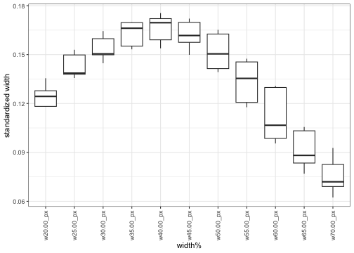

```r
body_condition_output$summaries$standardized_widths %>%
  ggplot() + theme_bw() +
  geom_boxplot(aes(x = metric, y = mean)) +
  theme(axis.text.x = element_text(angle = 90, vjust = 0.5, hjust=1)) +
  xlab("width%") + ylab("standardized width")
```

You can also view individual’s posterior samples for any of the body condition metrics.

```r
head(body_condition_output$body_area_index$`GW_01`$samples)
```

[output not shown]

And from these posterior samples for an individual, we can plot the distribution. Here we’ll plot BAI as an example, and include the 95% HPDI. Remember to exclude the first half of the samples, as mentioned above.

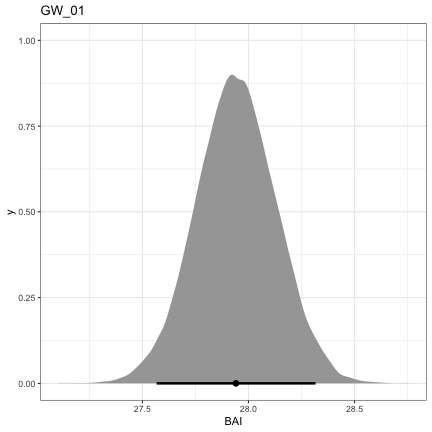

```r
ID_samples <- body_condition_output$body_area_index$`GW_01 1`$samples

data.frame(BAI = ID_samples[(length(ID_samples)/2):length((ID_samples))]) %>%
  ggplot() + stat_halfeye(aes(BAI), .width = 0.95) + theme_bw() + ggtitle("GW_01")
```

We hope this vignette has been helpful for getting started with organizing your input data and how to view and interpret results. Check out our other vignettes to view examples of other samplers, including using “informative priors” and “growth curves”.